# **2022 Year in Books**

Michael Gillis

Every year I track the books that I read through the website Goodreads. Goodreads is a website that began in 2006, and has since been purchased by Amazon. It allows for a user to select books from their extensive catalog, adding the books to shelves like “Read” and “Want to Read.” Users can also rate books using a 5 star rating system.

At the end of every year, Goodreads compiles a “Year in Books” for each user. It displays different data, such as total pages read, total books read, and average rating. I found myself wishing that Goodreads would provide more in this annual summary, which lead me to realize that all of the data I needed to create my own exists within the Goodreads catalog already.

Without further ado, here is my **2022** year in books:

# **Books**

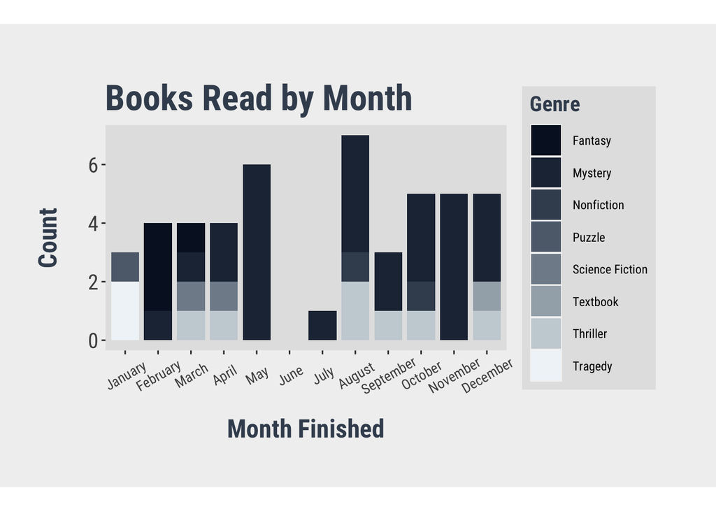

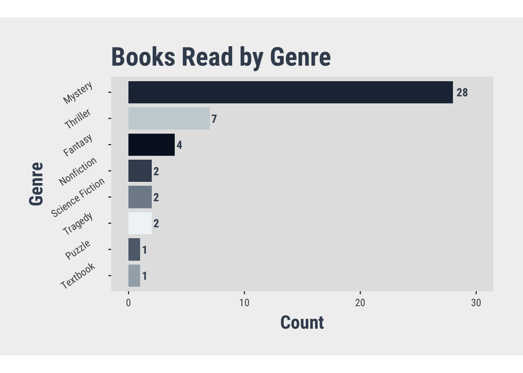

I read a total of **47** books this year.  
The genre I read the most of this year was **Mystery**, with a total of **28** **Mystery** books read.  
I read the most books in **August**, with a total of **7** books read that month.

# **Pages**

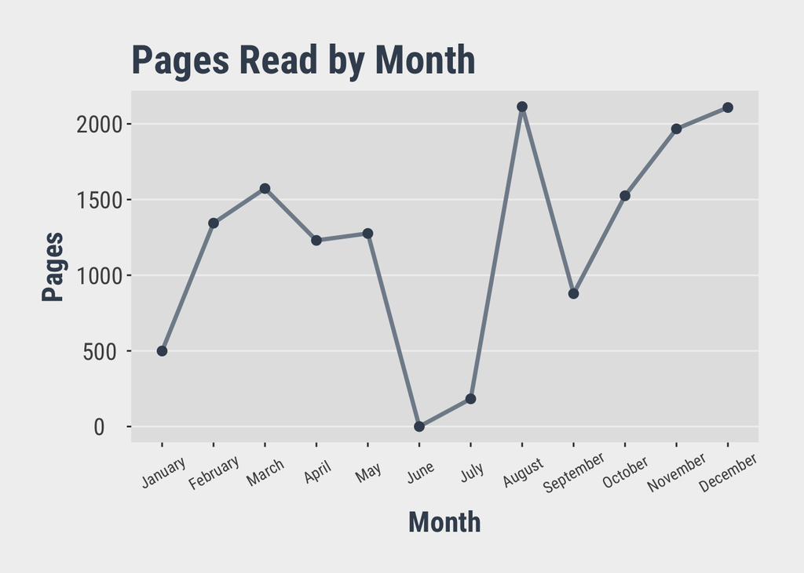

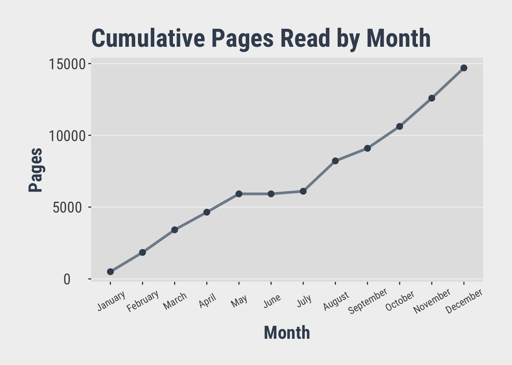

I read a total of **14,697** pages this year. I read an average of **313** pages per book.  
I read the most pages in **August** reading a total of **2,114** pages that month.  
The longest book I read this year was **Dan Brown**’s **Digital Fortress**, which has **525** pages.

# **Authors**

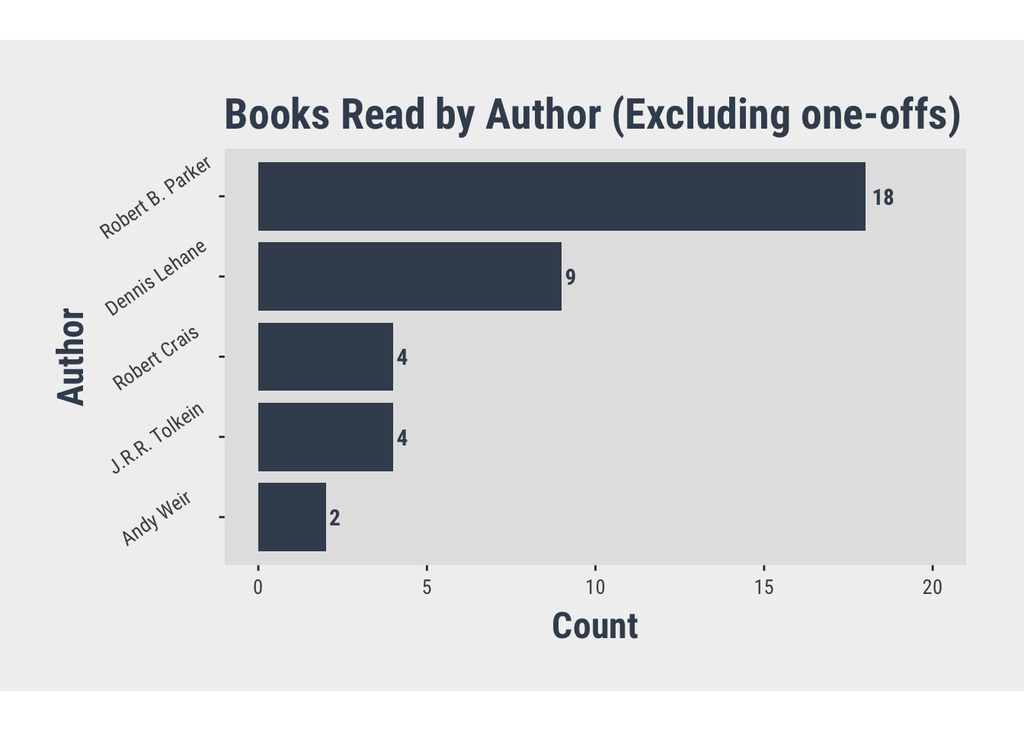

The author I read most from this year was **Robert B. Parker**. I read a total of **18** of their books.  
There were **10** “one-off” authors, or authors from which I only read a single book.

# **Reviews**

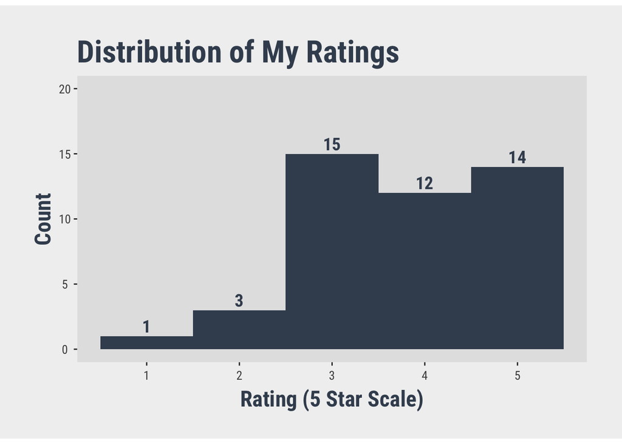

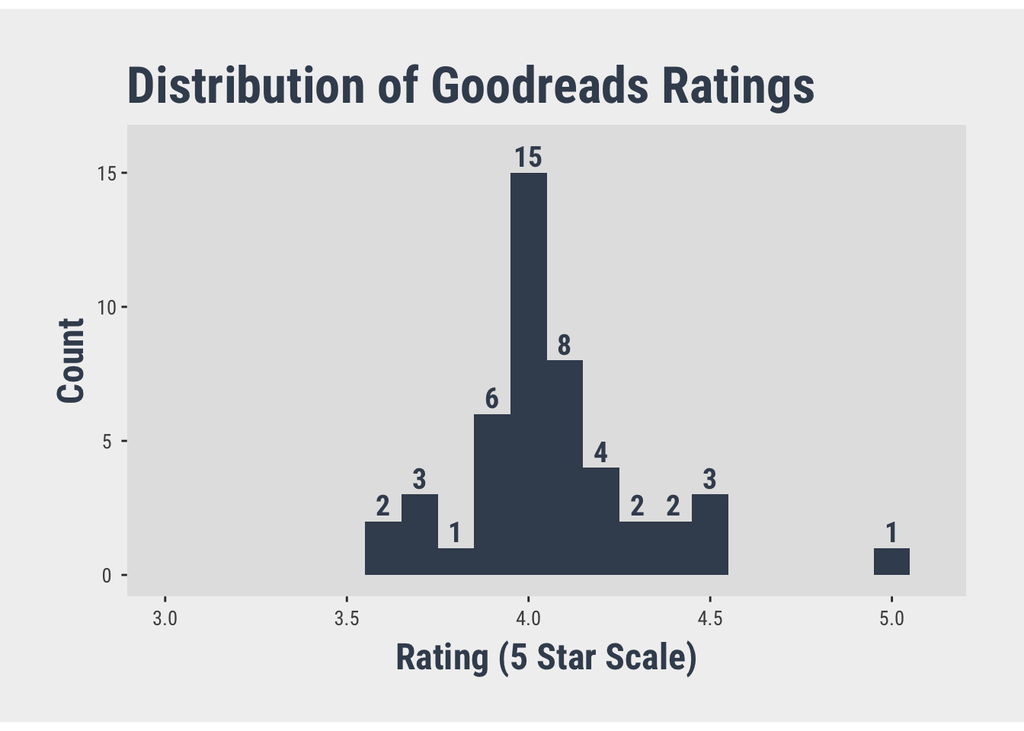

I reviewed a total of **45** books this year. The average rating that I gave to a book was **3.78** **Stars**.  
I gave **14** books 5 Stars this year.  
The average rating from Goodreads users of books that I read this year was **4.07** **Stars**.

# **Books Read**

## All Books Read

Here are all the books I read in **2022**:

| Month Finished | Title | Author | Genre | Pages | My Rating | Goodreads Rating |
| --- | --- | --- | --- | --- | --- | --- |
| December | Pastime | Robert B. Parker | Mystery | 223 | 3 | 3.99 |
| December | Prayers for Rain | Dennis Lehane | Mystery | 416 | 4 | 4.09 |
| December | Digital Fortress | Dan Brown | Thriller | 525 | 3 | 3.69 |
| December | Multivariable Calculus | James Stewart | Textbook | 512 | NA | 3.82 |
| December | Gone, Baby, Gone | Dennis Lehane | Mystery | 432 | 4 | 4.15 |
| November | Stardust | Robert B. Parker | Mystery | 268 | 4 | 3.92 |
| November | Racing the Light | Robert Crais | Mystery | 355 | 3 | 4.29 |
| November | Mystic River | Dennis Lehane | Mystery | 448 | 5 | 4.16 |
| November | Sacred | Dennis Lehane | Mystery | 416 | 3 | 3.95 |
| November | Darkness, Take My Hand | Dennis Lehane | Mystery | 480 | 5 | 4.17 |
| October | The Cuckoo’s Egg | Clifford Stoll | Nonfiction | 399 | 5 | 4.27 |
| October | Playmates | Robert B. Parker | Mystery | 272 | 3 | 3.94 |
| October | Since We Fell | Dennis Lehane | Thriller | 419 | 3 | 3.61 |
| October | The Drop | Dennis Lehane | Mystery | 224 | 3 | 3.74 |
| October | Crimson Joy | Robert B. Parker | Mystery | 211 | 4 | 3.96 |
| September | Pale Kings and Princes | Robert B. Parker | Mystery | 256 | 3 | 4.01 |
| September | Taming A Sea-Horse | Robert B. Parker | Mystery | 250 | 3 | 3.97 |
| September | Back of Beyond | C.J. Box | Thriller | 372 | 5 | 4.09 |
| August | Unbound | Stuart Woods | Thriller | 318 | 1 | 3.98 |
| August | A Drink Before the War | Dennis Lehane | Mystery | 282 | 4 | 3.94 |
| August | Hostage | Robert Crais | Thriller | 478 | 3 | 4.04 |
| August | Alan Turing | David Boyle | Nonfiction | 112 | 2 | 3.60 |
| August | Shutter Island | Dennis Lehane | Mystery | 385 | 5 | 4.10 |
| August | A Catskill Eagle | Robert B. Parker | Mystery | 311 | 3 | 4.05 |
| August | Valediction | Robert B. Parker | Mystery | 228 | 3 | 4.05 |
| July | The Widening Gyre | Robert B. Parker | Mystery | 183 | 4 | 3.99 |
| May | Ceremony | Robert B. Parker | Mystery | 219 | 4 | 4.00 |
| May | A Savage Place | Robert B. Parker | Mystery | 192 | 4 | 4.00 |
| May | Early Autumn | Robert B. Parker | Mystery | 221 | 5 | 4.14 |
| May | Looking for Rachel Wallace | Robert B. Parker | Mystery | 219 | 5 | 4.10 |
| May | The Judas Goat | Robert B. Parker | Mystery | 207 | 3 | 4.07 |
| May | Promised Land | Robert B. Parker | Mystery | 218 | 3 | 3.97 |
| April | Mortal Stakes | Robert B. Parker | Mystery | 192 | 5 | 4.01 |
| April | God Save the Child | Robert B. Parker | Mystery | 205 | 4 | 3.95 |
| April | The Judge’s List | John Grisham | Thriller | 357 | 2 | 4.17 |
| April | Project Hail Mary | Andy Weir | Science Fiction | 476 | 5 | 4.52 |
| March | The Martian | Andy Weir | Science Fiction | 387 | 5 | 4.41 |
| March | The Promise | Robert Crais | Mystery | 402 | 4 | 4.24 |
| March | Demolition Angel | Robert Crais | Thriller | 480 | 5 | 4.03 |
| March | The Fall of Gondolin | J.R.R. Tolkein | Fantasy | 304 | 2 | 4.06 |
| February | The Godwulf Manuscript | Robert B. Parker | Mystery | 208 | 4 | 3.92 |
| February | The Return of the King | J.R.R. Tolkein | Fantasy | 406 | 5 | 4.55 |
| February | The Two Towers | J.R.R. Tolkein | Fantasy | 323 | 5 | 4.47 |
| February | The Fellowship of the Ring | J.R.R. Tolkein | Fantasy | 407 | 5 | 4.38 |
| January | Hamlet | William Shakespeare | Tragedy | 342 | 3 | 4.03 |
| January | Oedipus Rex | Sophocles | Tragedy | 75 | 4 | 3.72 |
| January | Mini Math Crosswords | Brendan Sullivan | Puzzle | 82 | NA | 5.00 |

## Favorite Books Read

| Month Finished | Title | Author | Genre | Pages | My Rating | Goodreads Rating |
| --- | --- | --- | --- | --- | --- | --- |
| November | Mystic River | Dennis Lehane | Mystery | 448 | 5 | 4.16 |
| November | Darkness, Take My Hand | Dennis Lehane | Mystery | 480 | 5 | 4.17 |
| August | Shutter Island | Dennis Lehane | Mystery | 385 | 5 | 4.10 |
| May | Early Autumn | Robert B. Parker | Mystery | 221 | 5 | 4.14 |
| April | Project Hail Mary | Andy Weir | Science Fiction | 476 | 5 | 4.52 |
| March | The Martian | Andy Weir | Science Fiction | 387 | 5 | 4.41 |
| February | The Return of the King | J.R.R. Tolkein | Fantasy | 406 | 5 | 4.55 |
| February | The Two Towers | J.R.R. Tolkein | Fantasy | 323 | 5 | 4.47 |
| February | The Fellowship of the Ring | J.R.R. Tolkein | Fantasy | 407 | 5 | 4.38 |

# **Sources**

- **Packages:**
  - Tidyverse: https://www.tidyverse.org/
  - Knitr: https://cran.r-project.org/web/packages/knitr/index.html
- **Functions:**
  - Getmode: https://www.tutorialspoint.com/r/r_mean_median_mode.htm
  - Colorize: https://bookdown.org/yihui/rmarkdown-cookbook/font-color.html
  - Inline Hook: https://www.youtube.com/watch?v=a2MedFEQTeA